# INSPIRE Human Network Clustering

Gurkan Bebek

July 29, 2026

```r
required_packages <- c(
  "DBI", "RSQLite", "dplyr", "tidyr", "readr", "stringr",
  "ggplot2", "igraph", "pheatmap", "patchwork"
)

missing_packages <- required_packages[
  !vapply(required_packages, requireNamespace, logical(1), quietly = TRUE)
]

if (length(missing_packages) > 0) {
  stop("Install missing packages: ", paste(missing_packages, collapse = ", "))
}

library(DBI)
library(RSQLite)
library(dplyr)
library(tidyr)
library(readr)
library(stringr)
library(ggplot2)
library(igraph)
library(pheatmap)
library(patchwork)

set.seed(20260729)
dir.create(params$output_dir, recursive = TRUE, showWarnings = FALSE)
```

# 1 Purpose

This report analyzes the current human INSPIRE results after validating the executable with the GO normalization associated with the current GO cache.

The primary analysis uses the complete INSPIRE similarity matrix and hierarchical clustering. Two linkage methods are shown:

1. **Complete linkage**, as described in the manuscript Methods.
2. **Ward.D2**, because the historical figure command displayed Ward clustering.

Thresholded networks from 0.45 through 0.70 are secondary sensitivity analyses. They are not used to choose or manufacture a preferred primary clustering.

# 2 Database validation

```r
if (!file.exists(params$database)) {
  stop("Database not found: ", params$database)
}

con <- DBI::dbConnect(RSQLite::SQLite(), params$database)

integrity <- DBI::dbGetQuery(con, "PRAGMA integrity_check")[[1]][1]
if (!identical(integrity, "ok")) {
  stop("SQLite integrity check failed: ", integrity)
}

foreign_key_errors <- DBI::dbGetQuery(con, "PRAGMA foreign_key_check")
if (nrow(foreign_key_errors) > 0) {
  stop("SQLite foreign-key check returned errors")
}

petals <- DBI::dbGetQuery(
  con,
  "SELECT petal, gene_count, edge_count FROM petal ORDER BY petal"
)

petal_names <- petals$petal
n_petals <- length(petal_names)

if (n_petals < 3) stop("At least three petals are required")

petals
```

```
##      petal gene_count edge_count
## 1    ABCA1          6          6
## 2     BCL9          4          3
## 3    ERCC6          7          8
## 4    FBXW7         27         52
## 5      FN1         10         15
## 6     GLI3          6          7
## 7   IGFBP3          4          3
## 8     KRAS         23         44
## 9    MAP1B          4          3
## 10  MCM3AP          4          3
## 11    MMP2          5          5
## 12    NAV3          4          3
## 13     NF1         13         20
## 14  PIK3CA         25         46
## 15   PLCG2          4          3
## 16   PRKD1          7          8
## 17    PTEN         43         94
## 18 RUNX1T1          4          3
## 19   SMAD2         44         94
## 20   SMAD3         18         29
## 21   SMAD4         25         48
## 22    TAF2          6          6
## 23  TCF7L2         11         17
## 24  TGFBR2         20         32
## 25   TIAM1          6          7
## 26   UHRF2          5          5
## 27  ZNF521          4          3
```

# 3 GO-cache normalization audit

```r
go_audit <- DBI::dbGetQuery(
  con,
  paste(
    "SELECT algorithm,",
    "       COUNT(*) AS cached_pairs,",
    "       MIN(score) AS minimum_score,",
    "       MAX(score) AS maximum_score,",
    "       AVG(score) AS mean_score",
    "FROM go_pair_score",
    "WHERE algorithm = ?",
    "GROUP BY algorithm"
  ),
  params = list(params$go_algorithm)
)

if (nrow(go_audit) != 1) {
  stop("No GO cache was found for algorithm: ", params$go_algorithm)
}

normalization_difference <- abs(
  go_audit$maximum_score[1] - params$expected_go_normalization
)

if (normalization_difference > 1e-4) {
  stop(
    "GO-cache maximum is ", go_audit$maximum_score[1],
    " but expected_go_normalization is ", params$expected_go_normalization,
    ". Update the parameter or regenerate the correct logs."
  )
}

go_audit
```

```
##           algorithm cached_pairs minimum_score maximum_score mean_score
## 1 inspire_legacy_v1         5995     0.6542574      14.10263   10.51297
```

# 4 Read completed INSPIRE logs

```r
if (!dir.exists(params$inspire_log_dir)) {
  stop("INSPIRE log directory not found: ", params$inspire_log_dir)
}

log_files <- list.files(
  params$inspire_log_dir,
  pattern = "\\.log$|\\.txt$",
  full.names = TRUE
)

if (length(log_files) == 0) {
  stop("No INSPIRE .log or .txt files found in ", params$inspire_log_dir)
}

parse_inspire_log <- function(path) {
  lines <- readLines(path, warn = FALSE)
  result_lines <- grep("\\$RESULT\\$", lines, value = TRUE)
  normalization_lines <- grep("GO normalization in use:", lines, value = TRUE)

  normalization <- NA_real_
  if (length(normalization_lines) > 0) {
    normalization <- suppressWarnings(as.numeric(
      stringr::str_extract(tail(normalization_lines, 1), "[0-9]+(?:\\.[0-9]+)?")
    ))
  }

  if (length(result_lines) == 0) {
    return(tibble(
      log_file = path,
      petal_a = NA_character_,
      petal_b = NA_character_,
      score = NA_real_,
      normalization = normalization,
      status = "incomplete"
    ))
  }

  last_result <- tail(result_lines, 1)
  fields <- stringr::str_split(stringr::str_squish(last_result), "\\s+")[[1]]

  score_index <- which(fields == "norm_score:")
  if (length(score_index) != 1 || score_index + 1 > length(fields)) {
    return(tibble(
      log_file = path,
      petal_a = NA_character_,
      petal_b = NA_character_,
      score = NA_real_,
      normalization = normalization,
      status = "unparseable"
    ))
  }

  tibble(
    log_file = path,
    petal_a = fields[2],
    petal_b = fields[3],
    score = suppressWarnings(as.numeric(fields[score_index + 1])),
    normalization = normalization,
    status = "complete"
  )
}

log_results <- bind_rows(lapply(log_files, parse_inspire_log))

log_audit <- log_results |>
  count(status, name = "files")

log_audit
```

```
## # A tibble: 1 × 2
##   status   files
##   <chr>    <int>
## 1 complete   351
```

```r
reported_normalizations <- log_results |>
  filter(status == "complete", is.finite(normalization)) |>
  distinct(normalization) |>
  pull(normalization)

if (length(reported_normalizations) > 0 &&
    any(abs(reported_normalizations - params$expected_go_normalization) > 1e-4)) {
  stop(
    "At least one log used a different GO normalization: ",
    paste(reported_normalizations, collapse = ", ")
  )
}

incomplete_logs <- log_results |>
  filter(status != "complete" | !is.finite(score))

if (nrow(incomplete_logs) > 0) {
  write_csv(
    incomplete_logs,
    file.path(params$output_dir, "incomplete_or_unparseable_logs.csv")
  )
}

reported_normalizations
```

```
## [1] 14.1026
```

# 5 Build and validate the similarity matrix

```r
pair_results <- log_results |>
  filter(
    status == "complete",
    is.finite(score),
    petal_a %in% petal_names,
    petal_b %in% petal_names,
    petal_a != petal_b
  ) |>
  mutate(
    first = pmin(petal_a, petal_b),
    second = pmax(petal_a, petal_b)
  ) |>
  group_by(first, second) |>
  summarise(
    score = last(score),
    files = n(),
    .groups = "drop"
  )

expected_pairs <- choose(n_petals, 2)
observed_pairs <- nrow(pair_results)

pair_coverage <- tibble(
  petals = n_petals,
  expected_off_diagonal_pairs = expected_pairs,
  observed_off_diagonal_pairs = observed_pairs,
  coverage = observed_pairs / expected_pairs
)

pair_coverage
```

```
## # A tibble: 1 × 4
##   petals expected_off_diagonal_pairs observed_off_diagonal_pairs coverage
##    <int>                       <dbl>                       <int>    <dbl>
## 1     27                         351                         351        1
```

```r
expected_pair_table <- combn(petal_names, 2, simplify = FALSE) |>
  lapply(function(x) tibble(first = min(x), second = max(x))) |>
  bind_rows()

missing_pairs <- expected_pair_table |>
  anti_join(pair_results, by = c("first", "second"))

if (nrow(missing_pairs) > 0) {
  write_csv(
    missing_pairs,
    file.path(params$output_dir, "missing_inspire_pairs.csv")
  )

  stop(
    "INSPIRE matrix is incomplete: ", nrow(missing_pairs),
    " of ", expected_pairs, " off-diagonal pairs are missing. See missing_inspire_pairs.csv."
  )
}

inspire_similarity <- matrix(
  NA_real_,
  nrow = n_petals,
  ncol = n_petals,
  dimnames = list(petal_names, petal_names)
)

diag(inspire_similarity) <- 1

for (i in seq_len(nrow(pair_results))) {
  a <- pair_results$first[i]
  b <- pair_results$second[i]
  inspire_similarity[a, b] <- pair_results$score[i]
  inspire_similarity[b, a] <- pair_results$score[i]
}

if (anyNA(inspire_similarity)) stop("INSPIRE matrix contains missing values")
if (max(abs(inspire_similarity - t(inspire_similarity))) > 1e-10) {
  stop("INSPIRE matrix is not symmetric")
}
if (any(inspire_similarity < 0 | inspire_similarity > 1)) {
  stop("INSPIRE matrix contains values outside [0,1]")
}

write.csv(
  inspire_similarity,
  file.path(params$output_dir, "similarity_inspire_current_human.csv"),
  quote = FALSE
)
```

# 6 Positive-control scores

```r
get_pair_score <- function(a, b, similarity) {
  if (!a %in% rownames(similarity) || !b %in% colnames(similarity)) return(NA_real_)
  similarity[a, b]
}

positive_controls <- tibble(
  pair = c("SMAD2-SMAD3", "SMAD2-SMAD4", "SMAD3-SMAD4", "NF1-KRAS"),
  petal_a = c("SMAD2", "SMAD2", "SMAD3", "NF1"),
  petal_b = c("SMAD3", "SMAD4", "SMAD4", "KRAS")
) |>
  rowwise() |>
  mutate(score = get_pair_score(petal_a, petal_b, inspire_similarity)) |>
  ungroup()

all_off_diagonal <- inspire_similarity[upper.tri(inspire_similarity)]

positive_controls <- positive_controls |>
  mutate(
    percentile_among_all_pairs = vapply(
      score,
      function(x) if (is.na(x)) NA_real_ else mean(all_off_diagonal <= x),
      numeric(1)
    )
  )

write_csv(
  positive_controls,
  file.path(params$output_dir, "positive_control_scores.csv")
)

positive_controls
```

```
## # A tibble: 4 × 5
##   pair        petal_a petal_b score percentile_among_all_pairs
##   <chr>       <chr>   <chr>   <dbl>                      <dbl>
## 1 SMAD2-SMAD3 SMAD2   SMAD3   0.714                      0.949
## 2 SMAD2-SMAD4 SMAD2   SMAD4   0.720                      0.954
## 3 SMAD3-SMAD4 SMAD3   SMAD4   0.428                      0.840
## 4 NF1-KRAS    NF1     KRAS    0.620                      0.923
```

# 7 Score distribution

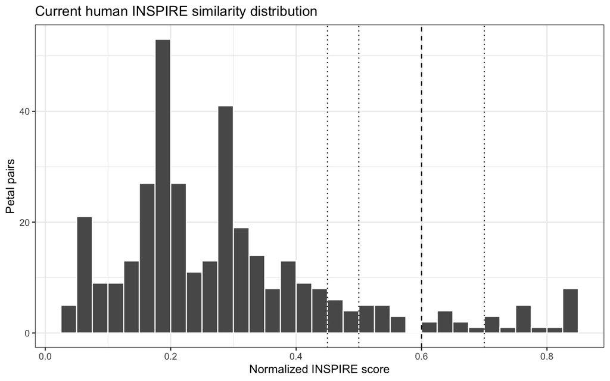

```r
score_long <- pair_results |>
  transmute(petal_a = first, petal_b = second, score = score)

score_summary <- score_long |>
  summarise(
    pairs = n(),
    minimum = min(score),
    first_quartile = quantile(score, 0.25),
    median = median(score),
    mean = mean(score),
    third_quartile = quantile(score, 0.75),
    maximum = max(score),
    above_0_45 = sum(score > 0.45),
    above_0_50 = sum(score > 0.50),
    above_0_60 = sum(score > 0.60),
    above_0_70 = sum(score > 0.70)
  )

write_csv(
  score_summary,
  file.path(params$output_dir, "inspire_score_summary.csv")
)

ggplot(score_long, aes(score)) +
  geom_histogram(binwidth = 0.025, boundary = 0, color = "white") +
  geom_vline(
    xintercept = c(0.45, 0.50, 0.60, 0.70),
    linetype = c(3, 3, 2, 3)
  ) +
  theme_bw() +
  labs(
    title = "Current human INSPIRE similarity distribution",
    x = "Normalized INSPIRE score",
    y = "Petal pairs"
  )
```

```r
score_summary
```

```
## # A tibble: 1 × 11
##   pairs minimum first_quartile median  mean third_quartile maximum above_0_45
##   <int>   <dbl>          <dbl>  <dbl> <dbl>          <dbl>   <dbl>      <int>
## 1   351  0.0275          0.177  0.250 0.288          0.356   0.837         51
## # ℹ 3 more variables: above_0_50 <int>, above_0_60 <int>, above_0_70 <int>
```

# 8 Primary hierarchical clustering

```r
inspire_distance <- as.dist(1 - inspire_similarity)

hc_complete <- hclust(
  inspire_distance,
  method = "complete"
)

hc_ward <- hclust(
  inspire_distance,
  method = "ward.D2"
)
```

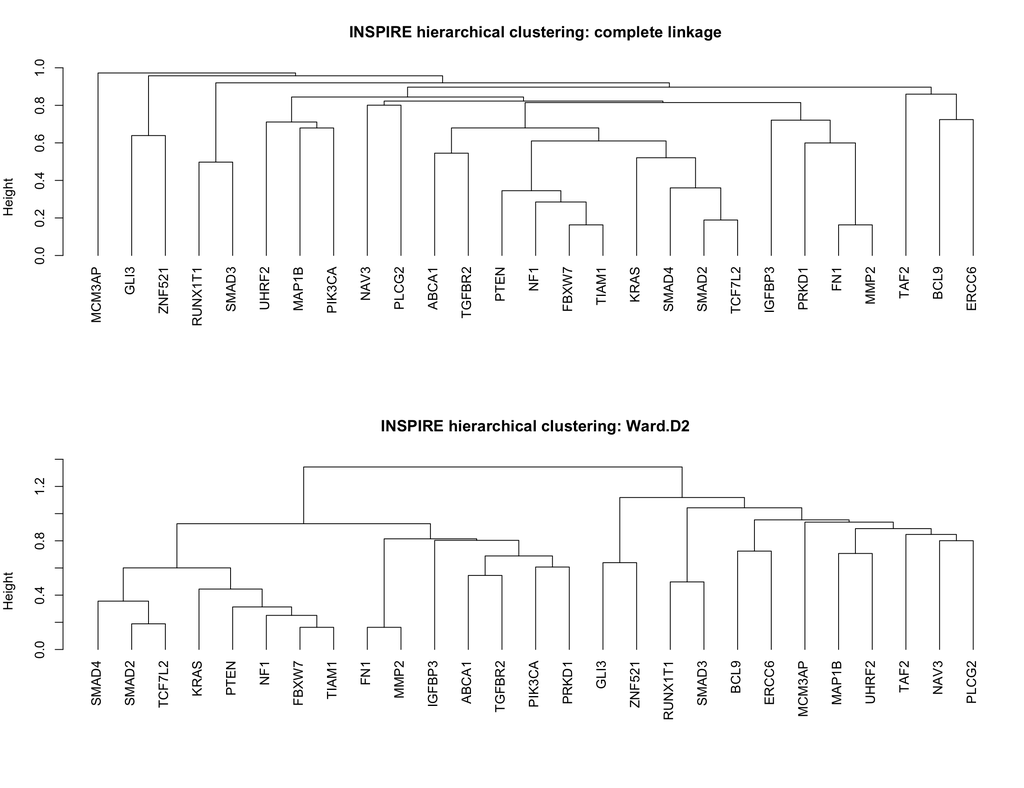

```r
old_par <- par(no.readonly = TRUE)
par(mfrow = c(2, 1), mar = c(4, 4, 4, 1))

plot(
  hc_complete,
  main = "INSPIRE hierarchical clustering: complete linkage",
  xlab = "",
  sub = "",
  hang = -1
)

plot(
  hc_ward,
  main = "INSPIRE hierarchical clustering: Ward.D2",
  xlab = "",
  sub = "",
  hang = -1
)
```

```r
par(old_par)
```

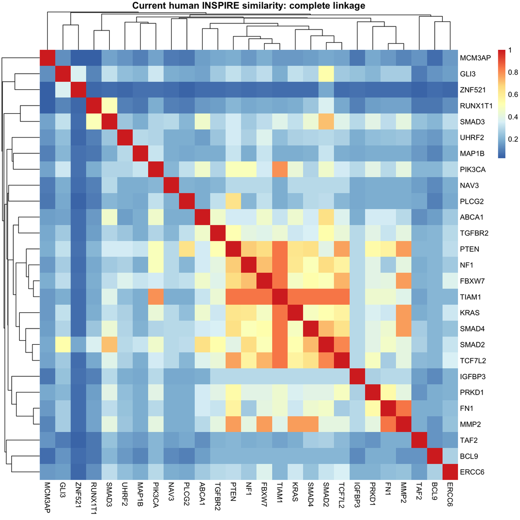

```r
pheatmap(
  inspire_similarity,
  clustering_distance_rows = inspire_distance,
  clustering_distance_cols = inspire_distance,
  clustering_method = "complete",
  main = "Current human INSPIRE similarity: complete linkage",
  border_color = NA
)
```

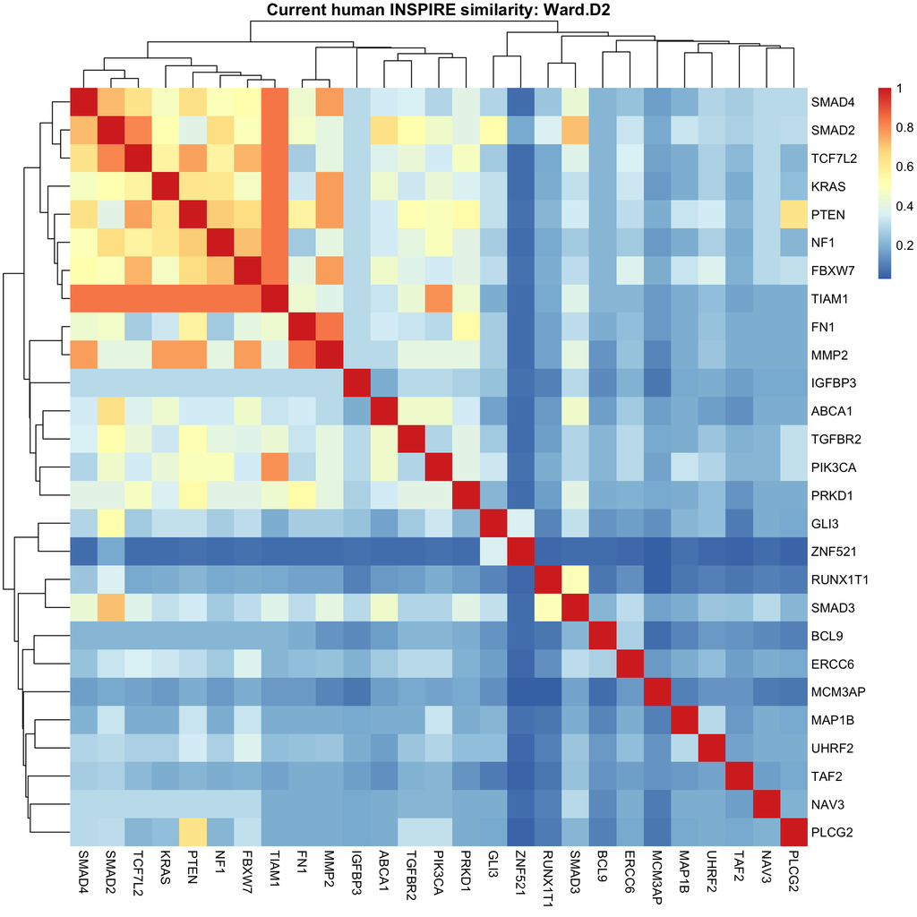

```r
pheatmap(
  inspire_similarity,
  clustering_distance_rows = inspire_distance,
  clustering_distance_cols = inspire_distance,
  clustering_method = "ward.D2",
  main = "Current human INSPIRE similarity: Ward.D2",
  border_color = NA
)
```

# 9 Inspect cluster solutions without selecting a single k

```r
k_values <- 2:min(10, n_petals - 1)

cluster_solutions <- bind_rows(lapply(k_values, function(k) {
  tibble(
    petal = petal_names,
    k = k,
    complete_cluster = unname(cutree(hc_complete, k = k)[petal_names]),
    ward_cluster = unname(cutree(hc_ward, k = k)[petal_names])
  )
}))

write_csv(
  cluster_solutions,
  file.path(params$output_dir, "hierarchical_cluster_solutions_k2_to_k10.csv")
)

cluster_solutions
```

[output not shown]

# 10 Secondary threshold sensitivity analysis

```r
thresholds <- seq(
  params$threshold_min,
  params$threshold_max,
  by = params$threshold_step
)

threshold_rows <- vector("list", length(thresholds))
component_rows <- vector("list", length(thresholds))
walktrap_rows <- vector("list", length(thresholds))

for (index in seq_along(thresholds)) {
  threshold <- thresholds[index]

  retained_edges <- score_long |>
    filter(score > threshold) |>
    transmute(from = petal_a, to = petal_b, weight = score)

  graph <- graph_from_data_frame(
    retained_edges,
    directed = FALSE,
    vertices = tibble(name = petal_names)
  )

  components_result <- components(graph)

  if (ecount(graph) > 0) {
    walktrap_result <- cluster_walktrap(graph, weights = E(graph)$weight)
    walktrap_membership <- membership(walktrap_result)
  } else {
    walktrap_membership <- setNames(seq_along(petal_names), petal_names)
  }

  threshold_rows[[index]] <- tibble(
    threshold = threshold,
    retained_edges = nrow(retained_edges),
    retained_fraction = nrow(retained_edges) / nrow(score_long),
    isolated_petals = sum(degree(graph) == 0),
    connected_components = components_result$no,
    largest_component = max(components_result$csize),
    walktrap_communities = length(unique(walktrap_membership))
  )

  component_rows[[index]] <- tibble(
    threshold = threshold,
    petal = petal_names,
    component = unname(components_result$membership[petal_names])
  )

  walktrap_rows[[index]] <- tibble(
    threshold = threshold,
    petal = petal_names,
    community = unname(walktrap_membership[petal_names])
  )
}

threshold_summary <- bind_rows(threshold_rows)
component_assignments <- bind_rows(component_rows)
walktrap_assignments <- bind_rows(walktrap_rows)

write_csv(
  threshold_summary,
  file.path(params$output_dir, "threshold_grid_summary.csv")
)
write_csv(
  component_assignments,
  file.path(params$output_dir, "threshold_component_assignments.csv")
)
write_csv(
  walktrap_assignments,
  file.path(params$output_dir, "threshold_walktrap_assignments.csv")
)

threshold_summary
```

[output not shown]

[figure not shown]

```r
p_edges <- ggplot(threshold_summary, aes(threshold, retained_edges)) +
  geom_line() +
  geom_point() +
  geom_vline(xintercept = params$selected_threshold, linetype = 2) +
  theme_bw() +
  labs(title = "Retained INSPIRE edges", y = "Edges")

p_isolates <- ggplot(threshold_summary, aes(threshold, isolated_petals)) +
  geom_line() +
  geom_point() +
  geom_vline(xintercept = params$selected_threshold, linetype = 2) +
  theme_bw() +
  labs(title = "Isolated petals", y = "Isolates")

p_components <- ggplot(threshold_summary, aes(threshold, connected_components)) +
  geom_line() +
  geom_point() +
  geom_vline(xintercept = params$selected_threshold, linetype = 2) +
  theme_bw() +
  labs(title = "Connected components", y = "Components")

p_edges + p_isolates + p_components + plot_layout(ncol = 1)
```

# 11 Threshold network gallery

All panels use the same node coordinates. This allows direct visual comparison as edges disappear with increasing thresholds.

```r
lowest_threshold <- min(thresholds)
lowest_edges <- score_long |>
  filter(score > lowest_threshold) |>
  transmute(from = petal_a, to = petal_b, weight = score)

layout_graph <- graph_from_data_frame(
  lowest_edges,
  directed = FALSE,
  vertices = tibble(name = petal_names)
)

set.seed(20260729)
fixed_layout <- layout_with_fr(
  layout_graph,
  weights = E(layout_graph)$weight,
  niter = 2000
)
rownames(fixed_layout) <- V(layout_graph)$name
fixed_layout <- fixed_layout[petal_names, , drop = FALSE]

network_dir <- file.path(params$output_dir, "threshold_networks")
dir.create(network_dir, recursive = TRUE, showWarnings = FALSE)

pdf_path <- file.path(params$output_dir, "threshold_networks_all.pdf")
pdf(pdf_path, width = 10, height = 8, onefile = TRUE)

for (index in seq_along(thresholds)) {
  threshold <- thresholds[index]

  retained_edges <- score_long |>
    filter(score > threshold) |>
    transmute(from = petal_a, to = petal_b, weight = score)

  graph <- graph_from_data_frame(
    retained_edges,
    directed = FALSE,
    vertices = tibble(name = petal_names)
  )

  if (ecount(graph) > 0) {
    communities <- membership(cluster_walktrap(graph, weights = E(graph)$weight))
  } else {
    communities <- setNames(seq_along(petal_names), petal_names)
  }

  palette <- hcl.colors(max(communities), palette = "Dark 3")
  node_colors <- palette[communities[V(graph)$name]]
  node_degree <- degree(graph)
  node_shapes <- ifelse(node_degree == 0, "square", "circle")
  node_frames <- ifelse(node_degree == 0, "black", "grey30")

  edge_widths <- if (ecount(graph) > 0) {
    1 + 5 * (E(graph)$weight - threshold) / max(1e-12, 1 - threshold)
  } else {
    numeric(0)
  }

  title_text <- paste0(
    "INSPIRE > ", sprintf("%.3f", threshold),
    " | edges: ", ecount(graph),
    " | components: ", components(graph)$no,
    " | isolates: ", sum(node_degree == 0)
  )

  draw_graph <- function() {
    plot(
      graph,
      layout = fixed_layout[V(graph)$name, , drop = FALSE],
      vertex.color = node_colors,
      vertex.frame.color = node_frames,
      vertex.shape = node_shapes,
      vertex.size = 24,
      vertex.label.cex = 0.8,
      edge.width = edge_widths,
      edge.color = adjustcolor("grey35", alpha.f = 0.55),
      main = title_text,
      margin = 0.12
    )
  }

  draw_graph()

  png_path <- file.path(
    network_dir,
    paste0("INSPIRE_threshold_", sprintf("%.3f", threshold), ".png")
  )

  png(png_path, width = 1800, height = 1400, res = 180)
  draw_graph()
  dev.off()

  cat("\n\n## Threshold ", sprintf("%.3f", threshold), "\n\n", sep = "")
  print(knitr::include_graphics(png_path))
  cat("\n\n")
}
```

## 11.1 Threshold 0.450

[1] “../reports/clustering_current_human/threshold_networks/INSPIRE_threshold_0.450.png” attr(,“class”) [1] “knit_image_paths” “knit_asis”

[figure not shown]

## 11.2 Threshold 0.475

[1] “../reports/clustering_current_human/threshold_networks/INSPIRE_threshold_0.475.png” attr(,“class”) [1] “knit_image_paths” “knit_asis”

[figure not shown]

## 11.3 Threshold 0.500

[1] “../reports/clustering_current_human/threshold_networks/INSPIRE_threshold_0.500.png” attr(,“class”) [1] “knit_image_paths” “knit_asis”

[figure not shown]

## 11.4 Threshold 0.525

[1] “../reports/clustering_current_human/threshold_networks/INSPIRE_threshold_0.525.png” attr(,“class”) [1] “knit_image_paths” “knit_asis”

[figure not shown]

## 11.5 Threshold 0.550

[1] “../reports/clustering_current_human/threshold_networks/INSPIRE_threshold_0.550.png” attr(,“class”) [1] “knit_image_paths” “knit_asis”

[figure not shown]

## 11.6 Threshold 0.575

[1] “../reports/clustering_current_human/threshold_networks/INSPIRE_threshold_0.575.png” attr(,“class”) [1] “knit_image_paths” “knit_asis”

[figure not shown]

## 11.7 Threshold 0.600

[1] “../reports/clustering_current_human/threshold_networks/INSPIRE_threshold_0.600.png” attr(,“class”) [1] “knit_image_paths” “knit_asis”

[figure not shown]

## 11.8 Threshold 0.625

[1] “../reports/clustering_current_human/threshold_networks/INSPIRE_threshold_0.625.png” attr(,“class”) [1] “knit_image_paths” “knit_asis”

[figure not shown]

## 11.9 Threshold 0.650

[1] “../reports/clustering_current_human/threshold_networks/INSPIRE_threshold_0.650.png” attr(,“class”) [1] “knit_image_paths” “knit_asis”

[figure not shown]

## 11.10 Threshold 0.675

[1] “../reports/clustering_current_human/threshold_networks/INSPIRE_threshold_0.675.png” attr(,“class”) [1] “knit_image_paths” “knit_asis”

[figure not shown]

[1] “../reports/clustering_current_human/threshold_networks/INSPIRE_threshold_0.700.png” attr(,“class”) [1] “knit_image_paths” “knit_asis”

```r
dev.off()
```

pdf 3

# 12 Selected-threshold assignments

```r
selected_index <- which.min(abs(thresholds - params$selected_threshold))
selected_threshold <- thresholds[selected_index]

selected_components <- component_assignments |>
  filter(abs(threshold - selected_threshold) < 1e-10) |>
  select(petal, component)

selected_walktrap <- walktrap_assignments |>
  filter(abs(threshold - selected_threshold) < 1e-10) |>
  select(petal, community)

selected_assignments <- selected_components |>
  left_join(selected_walktrap, by = "petal") |>
  arrange(component, community, petal)

write_csv(
  selected_assignments,
  file.path(params$output_dir, "selected_threshold_assignments.csv")
)

selected_assignments
```

```
## # A tibble: 27 × 3
##    petal  component community
##    <chr>      <dbl>     <dbl>
##  1 FBXW7          1         1
##  2 FN1            1         1
##  3 KRAS           1         1
##  4 MMP2           1         1
##  5 NF1            1         1
##  6 PIK3CA         1         1
##  7 PLCG2          1         1
##  8 PTEN           1         1
##  9 SMAD4          1         1
## 10 TCF7L2         1         1
## # ℹ 17 more rows
```

# 13 Analysis record

```r
analysis_record <- tibble(
  item = c(
    "GO algorithm",
    "GO normalization",
    "Petals",
    "Expected off-diagonal pairs",
    "Observed off-diagonal pairs",
    "Primary clustering 1",
    "Primary clustering 2",
    "Threshold analysis role"
  ),
  value = c(
    params$go_algorithm,
    as.character(params$expected_go_normalization),
    as.character(n_petals),
    as.character(expected_pairs),
    as.character(observed_pairs),
    "complete linkage on 1 - INSPIRE similarity",
    "Ward.D2 on 1 - INSPIRE similarity",
    "secondary sensitivity analysis"
  )
)

write_csv(
  analysis_record,
  file.path(params$output_dir, "analysis_record.csv")
)

analysis_record
```

```
## # A tibble: 8 × 2
##   item                        value
##   <chr>                       <chr>
## 1 GO algorithm                inspire_legacy_v1
## 2 GO normalization            14.1026
## 3 Petals                      27
## 4 Expected off-diagonal pairs 351
## 5 Observed off-diagonal pairs 351
## 6 Primary clustering 1        complete linkage on 1 - INSPIRE similarity
## 7 Primary clustering 2        Ward.D2 on 1 - INSPIRE similarity
## 8 Threshold analysis role     secondary sensitivity analysis
```

# 14 Database metadata

```r
metadata <- DBI::dbGetQuery(
  con,
  "SELECT key, value FROM metadata ORDER BY key"
)

write_csv(
  metadata,
  file.path(params$output_dir, "database_metadata.csv")
)

metadata
```

```
##                                                       key
## 1                           annotation_loader_last_run_at
## 2                               annotation_loader_version
## 3                                   created_or_updated_at
## 4                                  duplicate_score_policy
## 5                                          edge_direction
## 6                                   go_annotation_version
## 7                                        go_aspect_policy
## 8                                             go_gaf_file
## 9                                        go_gaf_loaded_at
## 10                                          go_gaf_sha256
## 11                                       go_ic_population
## 12                                   go_ic_total_proteins
## 13                                          go_not_policy
## 14                                            go_obo_file
```

[output cut: 71 more lines]

# 15 Disconnect

```r
DBI::dbDisconnect(con)
```